# Tutorial

In this tutorial, we demonstrate the usage of SuperMap in integrative analyses of unpaired single-cell multimodal data. Here we showcase an example of RNA and ATAC modality. For testing reason, we uses a 10X Multimodal PBMC data download from [10X Genomics website](https://www.10xgenomics.com/datasets), which contains paired scRNA-seq and scATAC-seq profiles. Of note, we intentionally disregard the inherent pairing between modalities, treating them as unpaired to simulate real-world scenarios, with the cell pairing information used solely for performance evaluation.

## Necessary packages

In order to run this vignette, make sure the following packages are installed:

```r
library(BiocParallel)
library(dplyr)
library(ggplot2)
library(patchwork)
library(Seurat)
library(Signac)
library(GenomicRanges)
library(GenomeInfoDb)
library(EnsDb.Hsapiens.v86)
library(Matrix)
```

## Stage 1: Data processing

We begin by loading the downloaded data file and creating a SeuratObject for processing. The data contains paired scRNA-seq and scATAC-seq measurements, which will be intentionally treated as unpaired for this analysis.

```r
inputdata.10x <- Read10X_h5("pbmc_granulocyte_sorted_10k_filtered_feature_bc_matrix.h5") ## Read data from the file
rna_counts <- inputdata.10x$`Gene Expression`
atac_counts <- inputdata.10x$Peaks
pbmc <- CreateSeuratObject(counts = rna_counts,assay = 'RNA')    ## Creat SeuratObject
pbmc[["percent.mt"]] <- PercentageFeatureSet(pbmc, pattern = "^MT-")

annotations <- GetGRangesFromEnsDb(ensdb = EnsDb.Hsapiens.v86)
seqlevels(annotations) <- paste0('chr', seqlevels(annotations))
genome(annotations) <- "hg38"
pbmc.atac = CreateChromatinAssay(counts = atac_counts,sep = c(":", "-"),annotation = annotations,
                                 fragments = 'pbmc_granulocyte_sorted_10k_atac_fragments.tsv.gz')
pbmc[['ATAC']] = pbmc.atac
```

We conduct basic quality control by assessing the number of detected molecules for each modality and the percentage of mitochondrial content.

```r
pbmc <- subset(x = pbmc,subset = nCount_RNA < 25000 &nCount_RNA > 1000 &percent.mt < 20 &nCount_ATAC < 7e4 &nCount_ATAC > 5e3)
```

Next, we perform data normalization and dimensional reduction for visualization, following the Seurat pipeline. If you are unfamiliar with this workflow, please refer to their [tutorial](https://satijalab.org/seurat/articles/weighted_nearest_neighbor_analysis).

```r
DefaultAssay(pbmc) <- "RNA"
pbmc = NormalizeData(object = pbmc)
pbmc = FindVariableFeatures(pbmc,nfeatures = 3000)
pbmc = ScaleData(pbmc)
pbmc <- RunPCA(pbmc,features = VariableFeatures(object = pbmc),verbose = FALSE)

DefaultAssay(pbmc) <- "ATAC"
pbmc <- RunTFIDF(pbmc)
pbmc <- FindTopFeatures(pbmc, min.cutoff = 'q0')
pbmc <- RunSVD(pbmc)

pbmc <- FindMultiModalNeighbors(pbmc, reduction.list = list("pca", "lsi"), dims.list = list(1:50, 2:50))
pbmc <- RunUMAP(pbmc, nn.name = "weighted.nn", reduction.name = "wnn.umap", reduction.key = "wnnUMAP_")
```

We further incorporate cell annotation into the SeuratObject and visualize the data using UMAP.

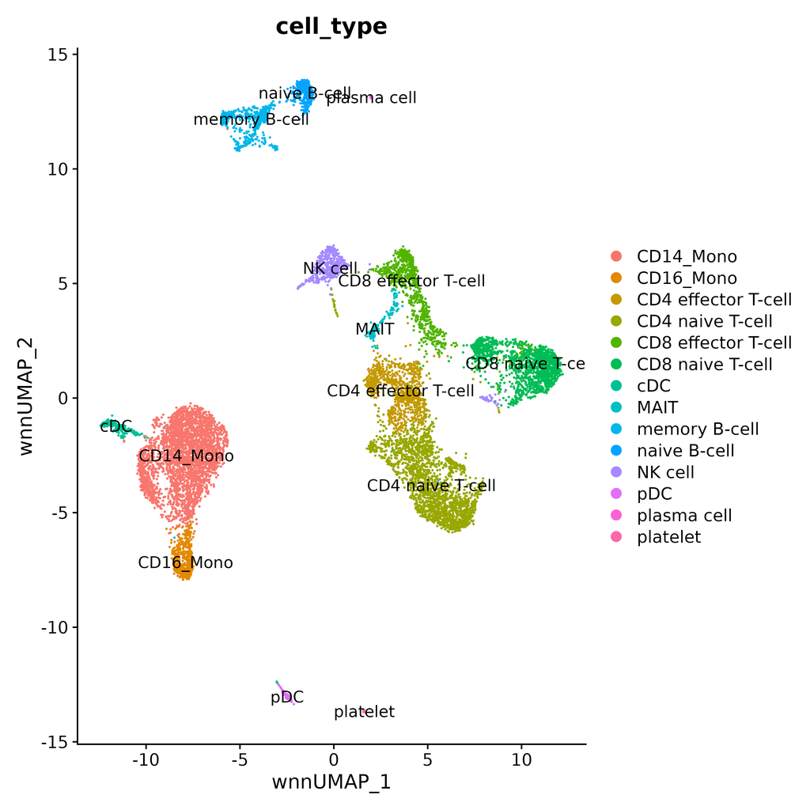

```r
cell_type = readRDS('cell_type.RDS')
pbmc$cell_type = cell_type[colnames(pbmc),'name']
DimPlot(pbmc,reduction = 'wnn.umap',label = TRUE,group.by = 'cell_type')
```

Single-cell data often exhibit sparsity and noise due to technical limitations, which presents significant challenges for accurate learning of cross-modal mappings. To mitigate this, SuperMap follows the approach established in previous studies by aggregating closely similar cells into “meta-cells” to enhance the signal to-noise ratio.

```r
pbmc <- res_cluster(object = pbmc,resolution = 28,graph.name = 'wsnn')  ## The clustering resolution can be flexibly adjusted.
metacell.pbmc.rna <- getmetacell_RNA(object = pbmc,cluster.name = "seurat_clusters")
metacell.pbmc.atac <- getmetacell_ATAC(object = pbmc,cluster.name = "seurat_clusters")
```

## Stage 2: Preparing input for SuperMap

We extract highly variable genes for subsequent calculations. If you have other genes of interest, you can also include them.

```r
variable_gene = VariableFeatures(pbmc,assay = 'RNA')
rna_high = metacell.pbmc.rna[,var_gene]
rna_high = t(rna_high)
atac = t(metacell.pbmc.atac)
```

SuperMap incorporates prior knowledge about the regulatory potential of the two modalities to regularize or constrain the model. Therefore, we need to compute a prior-related weight matrix $D$. For integrating scRNA-seq and scATAC-seq data, $D_{ij}$ is calculated using an exponential function $D_{ij} = exp(d_{ij}/d0)$, where $d_{ij}$ is the distance between the peak $j$ and the transcription start site of gene $i$, and $d0$ is a hyperparameter with a default value of 100 kb. This indicates that peak-gene regulatory interactions decay exponentially with distance. For computational efficiency and considering the high sparsity of $B$, $B_{ij}$ is set to 0 if $d_{ij}$ exceeds 200 kb or if gene $i$ and peak $j$ are located on different chromosomes.

```r
gene_ref = read.table('GRCh38_cellranger2020.gene_location.txt',sep = ' ',header = TRUE)   ## Read the genomic coordinates of all genes.
gene_name = rownames(rna_high)
match_gene = match(gene_ref$gene_name,gene_name)
gene_loc = gene_ref[!is.na(match_gene),]  ## Filter the genomic coordinates of genes of interest.
no_MT = (gene_loc$Chr != "chrM")
gene_loc = gene_loc[no_MT,]   ## Remove mitochondrial genes

match_gene_index = match_gene[!is.na(match_gene)]
index = which(duplicated(match_gene_index)==TRUE)
match_gene_index = match_gene_index[-index]
gene_loc = gene_loc[-index,]
no_MT = no_MT[-index]

rna_annot = rna_high[match_gene_index,]
rna_annot = rna_annot[no_MT,] ## Filter out mitochondrial genes from the data
TSS = gene_loc$start        ## Retrieve the positions of transcription start sites (TSS) for genes
TSS[gene_loc$strand=="-"] = gene_loc$end[gene_loc$strand=="-"]
gene_location = cbind(gene_loc$Chr,TSS)

peak_name = rownames(atac)
peak_name_split = str_split(peak_name,'-',simplify = TRUE)
peak_location = cbind(peak_name_split[,1],peak_name_split[,2])  ## Retrieve the positions of peaks in the ATAC data

b_nozero_index = Matrix::Matrix(nrow =dim(peak_location)[1],ncol = dim(gene_location)[1],data=0)
b_dis = Matrix::Matrix(nrow =dim(peak_location)[1],ncol = dim(gene_location)[1],data=0)
window_size=200000

## Compute the weight matrix D and the non-zero position index matrix in the coefficient matrix B.
for (i in 1:dim(gene_location)[1]) {
  index_matrix = crossing(i,1:dim(peak_location)[1])
  colnames(index_matrix) = c('gene','peak')
  chr_gene = gene_location[index_matrix$gene,1]
  chr_peak = peak_location[index_matrix$peak,1]
  loc_gene = gene_location[index_matrix$gene,2]
  loc_peak = peak_location[index_matrix$peak,2]
  chr_same = (chr_gene == chr_peak)
  loc_dis = abs(as.numeric(loc_peak) - as.numeric(loc_gene))
  loc_same = abs(as.numeric(loc_peak) - as.numeric(loc_gene)) < window_size
  chr_loc_same = chr_same&loc_same

  b_nozero_index[,i] = as.integer(chr_loc_same)
  b_dis[chr_loc_same,i] = loc_dis[chr_loc_same]
}


rna_annot = rna_annot[Matrix::colSums(b_nozero_index)>0,] ## Remove genes without nearby peaks
atac_annot = atac[Matrix::rowSums(b_nozero_index)>0,]
b_dis = b_dis[,Matrix::colSums(b_nozero_index)>0]   ## Update the distance matrix
b_dis = b_dis[Matrix::rowSums(b_nozero_index)>0,]
b_nozero_index = b_nozero_index[,Matrix::colSums(b_nozero_index)>0]   ## Update the index matrix
b_nozero_index = b_nozero_index[Matrix::rowSums(b_nozero_index)>0,]
colnames(b_nozero_index) = rownames(rna_annot)
rownames(b_nozero_index) = rownames(atac_annot)
colnames(b_dis) = rownames(rna_annot)
rownames(b_dis) = rownames(atac_annot)
```

Finally, we save the preprocessed data for use in the next stage.

```r
saveRDS(t(rna_annot),'rna_cal.RDS')

saveRDS(t(atac_annot),'atac_cal')

saveRDS(b_nozero_index,'b_01_index.RDS')

saveRDS(b_dis,'b_dis.RDS')
```

## Stage 3: Run SuerpMap

At this stage, we run SuperMap. First, read the preprocessed data, including the RNA data matrix, ATAC data matrix, weight matrix $D$, and index matrix.

```r
openblasctl::openblas_set_num_threads(50)  ## Set the number of threads to 50
rna_cal = readRDS('rna_cal.RDS')
atac_cal = readRDS('atac_cal.RDS')
distance = as.matrix(readRDS('b_dis.RDS'))
b_01_index = as.matrix(readRDS('b_01_index.RDS'))
```

SuperMap has three hyperparameters that need to be specified: (1) $w$ for weighting marginal distributions and pairwise interactions, (2) $\rho$ for the dual variable parameter, and (3) $\lambda$ for the prior penalty parameter. We found that SuperMap exhibits notable robustness against variations in the hyperparameters. Here, we run SuperMap using the default values.

```r
result = supermap(Y_unpaired = rna_cal, X_unpaired = atac_cal, index_B_nonzero = b_01_index, B_dist = distance,
                  w = 2, rho = 1, lambda_prior = 1*10^(-4))
```

As shown in the above code, SuperMap requires four matrices as input:

- Y_unpaired: The data matrix for modality 1, such as the gene expression matrix.
- X_unpaired: The data matrix for modality 2, such as the chromatin accessibility matrix.
- index_B_nonzero: The index matrix of non-zero positions in the coefficient matrix B, generated in Stage 2.
- B_dist: The prior-related weight matrix D, generated in Stage 2.

The returned results include the convergence of the model and the estimated parameters. We first plot the convergence curve for this run to check the iteration process.

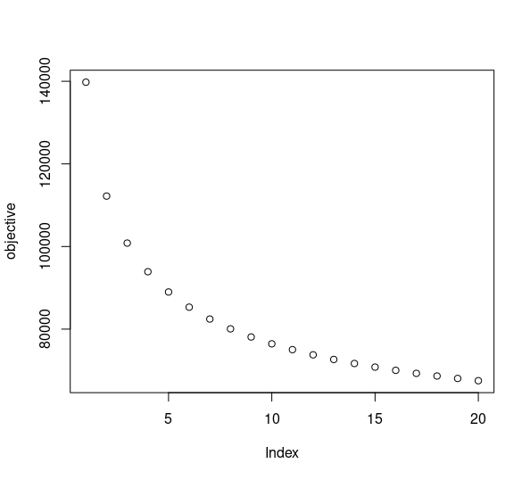

```r
loss = result$convergence
loss = as.data.frame(loss)

colnames(loss) = c('residual','objective')
loss$iter = c(1:nrow(loss))

plot(loss$objective)
```

Then, extract the estimated parameter $\hat{B}$

```r
b_hat = rbind(result_our$estimated_intercept,result_our$estimate_b)
```

$\hat{B}$ can be used for extensive downstream integrative analyses of unpaired multimodal data. These applications include: (1) enhancing cell-type identification by imputing missing modalities through estimated mappings, such as inferring marker genes’ expression in ATAC cells where such information is absent yet crucial for cell annotation; (2) providing informative inputs for diagonal integration thereby improving modality alignment; (3) enabling regulatory analysis on unpaired data by estimating cross-modal regulation strengths; and (4) revealing epigenomic priming events to specify cell differentiation directions along the trajectory.

In the next stage, we will demonstrate how to apply SuperMap for downstream analyses.